# Medical Appointment No Shows Dataset Exploration

## by: Abdullah Raslan

## Preliminary Wrangling

> This dataset includes information about more than 100,000 medical appointments for patients in Brazil and many of them did not show up in their scheduled appointments.

```python
import numpy as np
import pandas as pd
import matplotlib.pyplot as plt
import seaborn as sb

%matplotlib inline
```

```python
df = pd.read_csv('no-showup_data.csv')
df.head()
```

|  | PatientId | AppointmentID | Gender | ScheduledDay | AppointmentDay | Age | Neighbourhood | Scholarship | Hipertension | Diabetes | Alcoholism | Handcap | SMS_received | No-show |
| --- | --- | --- | --- | --- | --- | --- | --- | --- | --- | --- | --- | --- | --- | --- |
| 0 | 2.987250e+13 | 5642903 | F | 2016-04-29T18:38:08Z | 2016-04-29T00:00:00Z | 62 | JARDIM DA PENHA | 0 | 1 | 0 | 0 | 0 | 0 | No |
| 1 | 5.589978e+14 | 5642503 | M | 2016-04-29T16:08:27Z | 2016-04-29T00:00:00Z | 56 | JARDIM DA PENHA | 0 | 0 | 0 | 0 | 0 | 0 | No |
| 2 | 4.262962e+12 | 5642549 | F | 2016-04-29T16:19:04Z | 2016-04-29T00:00:00Z | 62 | MATA DA PRAIA | 0 | 0 | 0 | 0 | 0 | 0 | No |
| 3 | 8.679512e+11 | 5642828 | F | 2016-04-29T17:29:31Z | 2016-04-29T00:00:00Z | 8 | PONTAL DE CAMBURI | 0 | 0 | 0 | 0 | 0 | 0 | No |
| 4 | 8.841186e+12 | 5642494 | F | 2016-04-29T16:07:23Z | 2016-04-29T00:00:00Z | 56 | JARDIM DA PENHA | 0 | 1 | 1 | 0 | 0 | 0 | No |

```python
# high-level overview of data shape and composition
print(df.shape)
print(df.dtypes)
```

```
(110527, 14)
PatientId         float64
AppointmentID       int64
Gender             object
ScheduledDay       object
AppointmentDay     object
Age                 int64
Neighbourhood      object
Scholarship         int64
Hipertension        int64
Diabetes            int64
Alcoholism          int64
Handcap             int64
SMS_received        int64
No-show            object
dtype: object
```

```python
df.describe()
```

|  | PatientId | AppointmentID | Age | Scholarship | Hipertension | Diabetes | Alcoholism | Handcap | SMS_received |
| --- | --- | --- | --- | --- | --- | --- | --- | --- | --- |
| count | 1.105270e+05 | 1.105270e+05 | 110527.000000 | 110527.000000 | 110527.000000 | 110527.000000 | 110527.000000 | 110527.000000 | 110527.000000 |
| mean | 1.474963e+14 | 5.675305e+06 | 37.088874 | 0.098266 | 0.197246 | 0.071865 | 0.030400 | 0.022248 | 0.321026 |
| std | 2.560949e+14 | 7.129575e+04 | 23.110205 | 0.297675 | 0.397921 | 0.258265 | 0.171686 | 0.161543 | 0.466873 |
| min | 3.921784e+04 | 5.030230e+06 | -1.000000 | 0.000000 | 0.000000 | 0.000000 | 0.000000 | 0.000000 | 0.000000 |
| 25% | 4.172614e+12 | 5.640286e+06 | 18.000000 | 0.000000 | 0.000000 | 0.000000 | 0.000000 | 0.000000 | 0.000000 |
| 50% | 3.173184e+13 | 5.680573e+06 | 37.000000 | 0.000000 | 0.000000 | 0.000000 | 0.000000 | 0.000000 | 0.000000 |
| 75% | 9.439172e+13 | 5.725524e+06 | 55.000000 | 0.000000 | 0.000000 | 0.000000 | 0.000000 | 0.000000 | 1.000000 |
| max | 9.999816e+14 | 5.790484e+06 | 115.000000 | 1.000000 | 1.000000 | 1.000000 | 1.000000 | 4.000000 | 1.000000 |

### What is the structure of your dataset?

> This dataset contains 110527 records of patient appointments. Each Patient have 10 characteristics most of them are categorical.

### What is/are the main feature(s) of interest in your dataset?

> The main interest is to find a relationship between a certain feature for patients and not showing up in their scheduled appointments.

### What features in the dataset do you think will help support your investigation into your feature(s) of interest?

> Age for example can be a big influencer in not showing up in the appointment, also if the patient has a scholarship or if he was Hipertensive, have diabetes, Alcoholist or a Handcap. All this characteristics might have an influence and will support my investigation.

## Primary Cleaning

```python
df_clean = df.copy()
```

#### 1- Column names have typos and hard to read.

Change the column names to be: (patient_id, appointment_id, gender, scheduled_timestamp, appointment_timestamp, age, neighbourhood, scholarship, hypertension, diabetes, alcoholism, handicap, sms_received, not_shown).

```python
column_names = ['patient_id', 'appointment_id', 'gender', 'scheduled_day', 'appointment_day','age',
          'neighbourhood', 'scholarship', 'hypertension','diabetes', 'alcoholism', 'handicap', 'sms_received', 'not_shown']
df_clean.columns = column_names
```

#### 2- `patient_id` is float type not string.

Convert `patient_id` column from floar into a string but firslty convert it to integer as a bridge.

```python
df_clean['patient_id'] = df_clean['patient_id'].astype('int64')
df_clean['patient_id'] = df_clean['patient_id'].astype('str')
```

#### 3- `appointment_id` is integer type not string.

Convert `appointment_id` column from integer into a string.

```python
df_clean['appointment_id'] = df_clean['appointment_id'].astype('str')
```

#### 4- `scheduled_day` and `appointment_day` columns are string types not datetime.

Convert `scheduled_day` and `appointment_day` columns from string to datetime data type

```python
df_clean['scheduled_day'] = pd.to_datetime(df_clean['scheduled_day'])
df_clean['appointment_day'] = pd.to_datetime(df_clean['appointment_day'])
```

#### 5- one of `age` column values equals to -1 which is not a reasonable value.

Drop row that contains `age` = -1

```python
df_clean.drop(df_clean.query('age < 0').index, axis=0, inplace=True)
```

#### 6- Adding a new column for appointment delay

Create a new column appointment_delay to calculate the difference between scheduled_day and appointment_day

```python
df_clean['appointment_delay'] = (df_clean.appointment_day - df_clean.scheduled_day).abs().dt.days
```

```python
df_clean.head()
```

|  | patient_id | appointment_id | gender | scheduled_day | appointment_day | age | neighbourhood | scholarship | hypertension | diabetes | alcoholism | handicap | sms_received | not_shown | appointment_delay |
| --- | --- | --- | --- | --- | --- | --- | --- | --- | --- | --- | --- | --- | --- | --- | --- |
| 0 | 29872499824296 | 5642903 | F | 2016-04-29 18:38:08+00:00 | 2016-04-29 00:00:00+00:00 | 62 | JARDIM DA PENHA | 0 | 1 | 0 | 0 | 0 | 0 | No | 0 |
| 1 | 558997776694438 | 5642503 | M | 2016-04-29 16:08:27+00:00 | 2016-04-29 00:00:00+00:00 | 56 | JARDIM DA PENHA | 0 | 0 | 0 | 0 | 0 | 0 | No | 0 |
| 2 | 4262962299951 | 5642549 | F | 2016-04-29 16:19:04+00:00 | 2016-04-29 00:00:00+00:00 | 62 | MATA DA PRAIA | 0 | 0 | 0 | 0 | 0 | 0 | No | 0 |
| 3 | 867951213174 | 5642828 | F | 2016-04-29 17:29:31+00:00 | 2016-04-29 00:00:00+00:00 | 8 | PONTAL DE CAMBURI | 0 | 0 | 0 | 0 | 0 | 0 | No | 0 |
| 4 | 8841186448183 | 5642494 | F | 2016-04-29 16:07:23+00:00 | 2016-04-29 00:00:00+00:00 | 56 | JARDIM DA PENHA | 0 | 1 | 1 | 0 | 0 | 0 | No | 0 |

```python
df_clean['appointment_delay'].describe()
```

```
count    110526.000000
mean          9.532915
std          15.027724
min           0.000000
25%           0.000000
50%           3.000000
75%          14.000000
max         178.000000
Name: appointment_delay, dtype: float64
```

#### 7- Change the type for the categorical features to 'categorical' and rename categories

Convert categorical columns from int to categorical data type

```python
df_clean['gender'] = df_clean['gender'].astype('category')
df_clean['sms_received'] = df_clean['sms_received'].astype('category')
df_clean['hypertension'] = df_clean['hypertension'].astype('category')
df_clean['not_shown'] = df_clean.not_shown.astype('category')
df_clean['alcoholism'] = df_clean['alcoholism'].astype('category')
df_clean['diabetes'] = df_clean['diabetes'].astype('category')
df_clean['scholarship'] = df_clean['scholarship'].astype('category')
```

```python
df_clean.gender.cat.rename_categories({'F':'Female','M':'Male'}, inplace = True)
df_clean.not_shown.cat.rename_categories({'No':'Show','Yes':'No Show'}, inplace = True)
df_clean.hypertension.cat.rename_categories({0:'Not Hypertensive', 1:'Hypertensive'}, inplace = True)
df_clean.sms_received.cat.rename_categories({0:'Not Received', 1:'Received'}, inplace = True)
df_clean.alcoholism.cat.rename_categories({0:'Not Alcoholist', 1:'Alcoholist'}, inplace = True)
df_clean.diabetes.cat.rename_categories({0:'Not Diabetic', 1:'Diabetic'}, inplace = True)
df_clean.scholarship.cat.rename_categories({0:'No Scholarship', 1:'Scholarship'}, inplace = True)
```

```python
df_clean.dtypes
```

```
patient_id                        object
appointment_id                    object
gender                          category
scheduled_day        datetime64[ns, UTC]
appointment_day      datetime64[ns, UTC]
age                                int64
neighbourhood                     object
scholarship                     category
hypertension                    category
diabetes                        category
alcoholism                      category
handicap                           int64
sms_received                    category
not_shown                       category
appointment_delay                  int64
dtype: object
```

```python
df_clean.to_csv('no_show_app_clean.csv')
```

## Univariate Exploration

> I'll start by looking at percentage of people who did not show up to the appointment.

```python
show_pie = df_clean.not_shown.value_counts()
show_pie
```

```
Show       88207
No Show    22319
Name: not_shown, dtype: int64
```

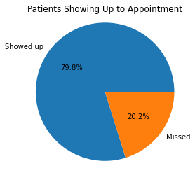

```python
plt.pie(show_pie, labels=['Showed up', 'Missed'], autopct='%1.1f%%');
plt.axis('square')
plt.title('Patients Showing Up to Appointment')

plt.show()
```

From the pie chart, I can conclude that the majority have showed up.

> Now I will be looking at the distribution of one variable of interest: Age

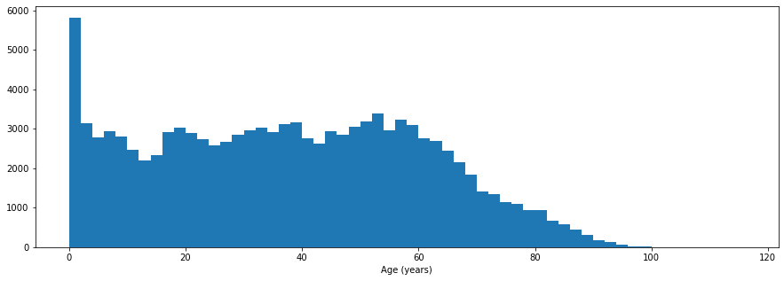

```python
binsize = 2
bins = np.arange(0, df_clean['age'].max()+binsize, binsize)

plt.figure(figsize=[15, 5])
plt.hist(data = df_clean, x = 'age', bins = bins)
plt.xlabel('Age (years)')
plt.show()
```

We can observe a peak in the smallest bin which represnts ages from 0 to 2 year.

> After that we need to see the distribution of genders per appointment

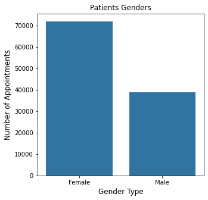

```python
plt.figure(figsize=(5,5))
base_color = sb.color_palette()[0]
plot_order = df_clean['gender'].value_counts().index
sb.countplot(data = df_clean, x='gender', color = base_color, order= plot_order)
plt.title('Patients Genders')
plt.ylabel('Number of Appointments', fontsize=12)
plt.xlabel('Gender Type', fontsize=12)
plt.show()
```

Most of patient appointments are Females.

> I'll now move on to the categorical variables:

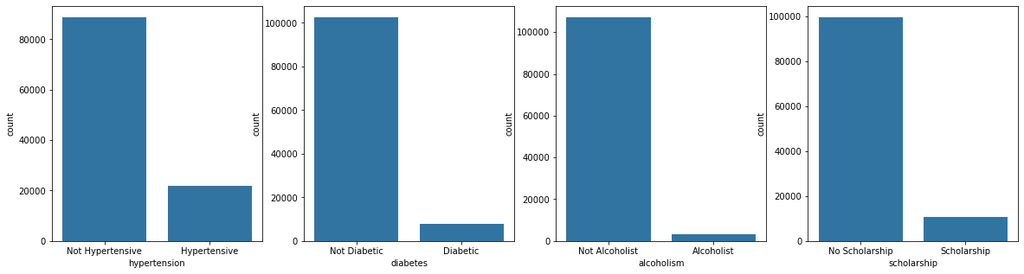

```python
plt.figure(figsize = [20, 5])
base_color = sb.color_palette()[0]


plt.subplot(1, 4, 1)
sb.countplot(data=df_clean, x='hypertension', color = base_color)


plt.subplot(1, 4, 2)
sb.countplot(data=df_clean, x='diabetes', color = base_color)


plt.subplot(1, 4, 3)
sb.countplot(data=df_clean, x='alcoholism', color = base_color);

plt.subplot(1, 4, 4)
sb.countplot(data=df_clean, x='scholarship', color = base_color);
```

Most Patients don't have Hypertension, Diabetes nor Alcoholism, also the majority do not have a scholarship

> Now I will have a look at Neighbourhoods of patients:

```python
type_count = df_clean.neighbourhood.value_counts()
type_order = type_count.index
```

```python
n_df = df_clean.shape[0]
max_type_count = type_count[0] / n_df
max_type_count
```

```
0.06982067567812099
```

```python
v_label = np.arange(0, max_type_count, 0.005)
v_label
```

```
array([0.   , 0.005, 0.01 , 0.015, 0.02 , 0.025, 0.03 , 0.035, 0.04 ,
       0.045, 0.05 , 0.055, 0.06 , 0.065])
```

```python
t_label = ['{:0.03f}'.format(v) for v in v_label]
```

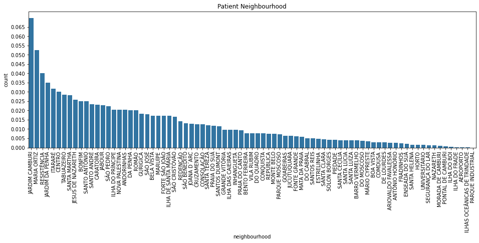

```python
plt.figure(figsize=(16,5))
coloring = sb.color_palette()[0]

sb.countplot(data = df_clean, x=  'neighbourhood', color=coloring, order=type_order);
plt.xticks(rotation=90);
plt.yticks(v_label*n_df ,t_label);
plt.title('Patient Neighbourhood')
plt.show()
```

Most of patients are from (JARDIM CAMBURI, MARIA ORTIZ, RESISTÊNCIA, JARDIM DA PENHA and ITARARÉ)

> Appointment delays also might be a factor than affects attending the appointment

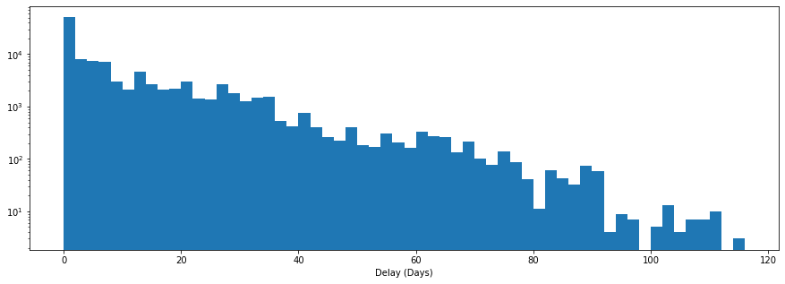

```python
plt.figure(figsize=[15, 5])
plt.hist(data = df_clean, x = 'appointment_delay', bins = bins)
plt.xlabel('Delay (Days)')
plt.yscale('log')
plt.show()
```

### Discuss the distribution(s) of your variable(s) of interest. Were there any unusual points? Did you need to perform any transformations?

> Normally most appointments have been attended so there is no unusual points in that pie chart. for gender I see that females are almost twice the males, so this will be under consideration in bivariate distributuion to use only the proportion.

### Of the features you investigated, were there any unusual distributions? Did you perform any operations on the data to tidy, adjust, or change the form of the data? If so, why did you do this?

> For the age of patients I observed that from 0-2 year have a peak compared to other ages. For now there will not be any transformation done. I made primary cleaning to be able to adjust the data. Appointment delays could be a factor that affects showing up to appointment.

## Bivariate Exploration

Now I need to see the relation between characteristics and showing up to appointment status to find if there is any correlation.

> Firstly we need to visualize the average age for each gender:

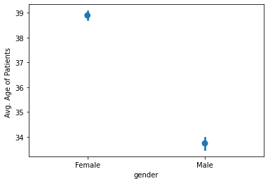

```python
sb.pointplot(data=df_clean, x='gender', y='age', color=base_color, linestyles="");
plt.ylabel('Avg. Age of Patients ');
```

On average males are younger than females. We also need to see if there are any age outliers in each gender:

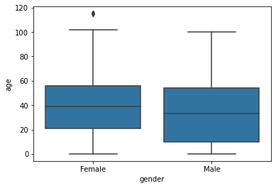

```python
sb.boxplot(data=df_clean, x='gender', y='age', color=base_color);
```

We can observe an outlier in females that is older than 110 years. But also median indicates the males are smaller on average than females.

> Now lets plot age with showing up status:

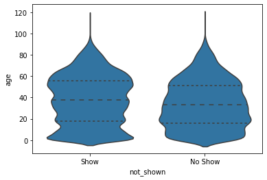

```python
sb.violinplot(data=df_clean, x='not_shown', y='age', inner = 'quartile', color = base_color);
```

> I also needed to see if there is a relation between delaying the appointment and not showing up:

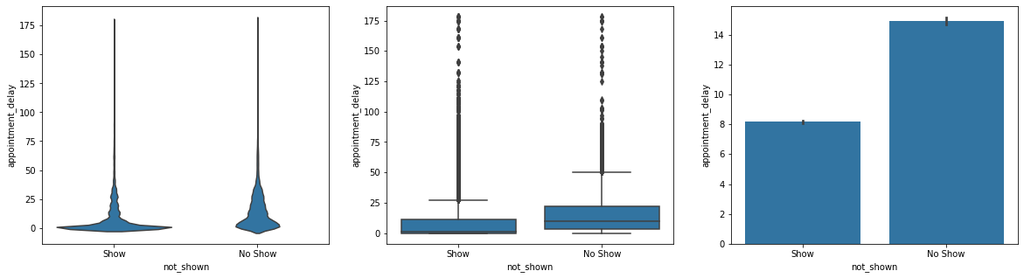

```python
plt.figure(figsize = [20, 5])

# left plot: violin plot
plt.subplot(1, 3, 1)
sb.violinplot(data=df_clean, x='not_shown', y='appointment_delay', inner = None, color = base_color)

# center plot: box plot
plt.subplot(1, 3, 2)
sb.boxplot(data=df_clean, x='not_shown', y='appointment_delay', color=base_color)

# right plot: adapted bar chart
plt.subplot(1, 3, 3)
sb.barplot(data=df_clean, x='not_shown', y='appointment_delay', color=base_color);
```

We can see that delaying mostly causes not showing up to appointments.

> Also for other charecterstics, we need to compare their proportions to get more insights about not showing up reasons.

> For patients with scholarships and their proportion of showing will be as follows:

```python
scholar_prop = (df_clean.groupby('not_shown').scholarship.value_counts() /
                          df_clean.groupby('scholarship').count().not_shown)
scholar_prop = scholar_prop.reset_index(name='proportion')
```

```python
scholar_prop = scholar_prop.pivot(index = 'scholarship', columns = 'not_shown', values = 'proportion')
scholar_prop
```

| not_shown scholarship | Show | No Show |
| --- | --- | --- |
| No Scholarship | 0.801926 | 0.198074 |
| Scholarship | 0.762637 | 0.237363 |

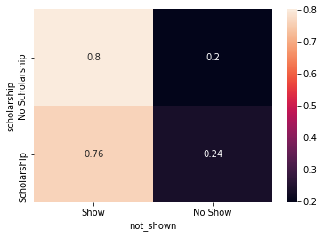

```python
sb.heatmap(scholar_prop, annot = True);
```

The proportion of showing up for patients with no scholarship are higher than those who have a scholarship.

> For other charecteristics of patient we also need to see if they affect not showing up to appointment or not:

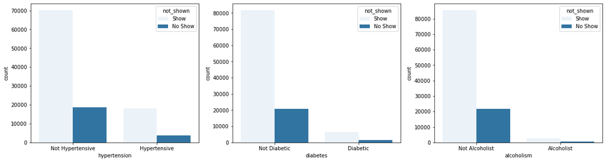

```python
plt.figure(figsize = [20, 5])
base_color = sb.color_palette()[0]


plt.subplot(1, 3, 1)
sb.countplot(data=df_clean, x='hypertension', hue='not_shown', color = base_color)


plt.subplot(1, 3, 2)
sb.countplot(data=df_clean, x='diabetes', hue='not_shown', color = base_color)


plt.subplot(1, 3, 3)
sb.countplot(data=df_clean, x='alcoholism', hue='not_shown', color = base_color);
```

We can't clearly see the correlation between characteristics and showing up status.

> Thus, we need to see the proportion instead of only count:

```python
hyper_prop = (df_clean.groupby('not_shown').hypertension.value_counts() /
                          df_clean.groupby('hypertension').count().not_shown)
hyper_prop = hyper_prop.reset_index(name='proportion')
diab_prop = (df_clean.groupby('not_shown').diabetes.value_counts() /
                          df_clean.groupby('diabetes').count().not_shown)
diab_prop = diab_prop.reset_index(name='proportion')
alc_prop = (df_clean.groupby('not_shown').alcoholism.value_counts() /
                          df_clean.groupby('alcoholism').count().not_shown)
alc_prop = alc_prop.reset_index(name='proportion')
```

```python
hyper_prop = hyper_prop.pivot(index = 'hypertension', columns = 'not_shown', values = 'proportion')
diab_prop = diab_prop.pivot(index = 'diabetes', columns = 'not_shown', values = 'proportion')
alc_prop = alc_prop.pivot(index = 'alcoholism', columns = 'not_shown', values = 'proportion')
```

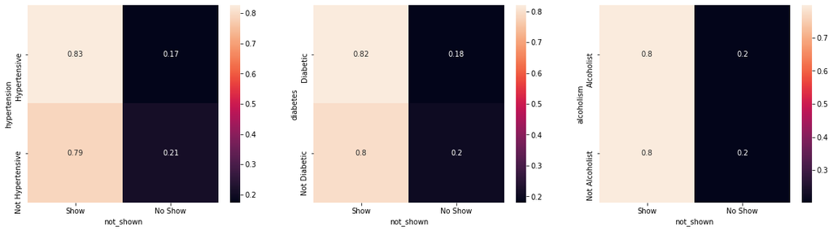

```python
plt.figure(figsize = [20, 5])
base_color = sb.color_palette()[0]


plt.subplot(1, 3, 1)
sb.heatmap(hyper_prop, annot = True);


plt.subplot(1, 3, 2)
sb.heatmap(diab_prop, annot = True);


plt.subplot(1, 3, 3)
sb.heatmap(alc_prop, annot = True);
```

A slight higher proportion is noticed for hypertensive or diabetic patients for showing up to appointments. For alcoholism feature there is no difference.

### Talk about some of the relationships you observed in this part of the investigation. How did the feature(s) of interest vary with other features in the dataset?

> Some of the variables that I noticed they affect not showing up to an appointment are:
> - **Appointment Delay**: not showing up status had a higher average delay days than shwowing up.
> - **Scholarship**: patients with scholarship tend to have a higher proportion in not showing up to an appointment compared to those who don't have a scholarship.
> - **Hypertension**: Not hypertensive patients have a higher proportion in not showing up to an appointment compared to those who are.
> - **Diabetes**: Not diabetic patients have a higher proportion in not showing up to an appointment compared to those who are.

### Did you observe any interesting relationships between the other features (not the main feature(s) of interest)?

> Until the moment I didn't observe a relationship between other factors but this will be more clear in a multivariate exploration to variables.

## Multivariate Exploration

I will now dig more deeply and in further details to the features of interest by using a multivariate visualizations.

```python
np.random.seed(2018)
sample = np.random.choice(df_clean.shape[0] , 200, replace=False)
df_clean_subset= df_clean.loc[sample]
df_clean_subset.head()
```

|  | patient_id | appointment_id | gender | scheduled_day | appointment_day | age | neighbourhood | scholarship | hypertension | diabetes | alcoholism | handicap | sms_received | not_shown | appointment_delay |
| --- | --- | --- | --- | --- | --- | --- | --- | --- | --- | --- | --- | --- | --- | --- | --- |
| 30946 | 8236461184191 | 5639574 | Male | 2016-04-29 09:14:50+00:00 | 2016-05-11 00:00:00+00:00 | 15 | ESTRELINHA | No Scholarship | Not Hypertensive | Not Diabetic | Not Alcoholist | 0 | Received | Show | 11 |
| 95146 | 24981643661387 | 5772131 | Female | 2016-06-03 14:39:13+00:00 | 2016-06-03 00:00:00+00:00 | 17 | NOVA PALESTINA | No Scholarship | Not Hypertensive | Not Diabetic | Not Alcoholist | 0 | Not Received | Show | 0 |
| 58161 | 2142946827583 | 5678394 | Male | 2016-05-10 08:27:55+00:00 | 2016-05-10 00:00:00+00:00 | 41 | JARDIM CAMBURI | No Scholarship | Not Hypertensive | Not Diabetic | Not Alcoholist | 0 | Not Received | Show | 0 |
| 54256 | 267697118999921 | 5683643 | Female | 2016-05-11 07:43:41+00:00 | 2016-05-18 00:00:00+00:00 | 4 | SÃO PEDRO | No Scholarship | Not Hypertensive | Not Diabetic | Not Alcoholist | 0 | Not Received | No Show | 6 |
| 109700 | 72642946795599 | 5751448 | Female | 2016-05-31 10:08:59+00:00 | 2016-06-07 00:00:00+00:00 | 53 | BENTO FERREIRA | No Scholarship | Not Hypertensive | Not Diabetic | Not Alcoholist | 0 | Not Received | No Show | 6 |

> Could appointment delay to has a different impact for showing up to appointment on different ages of patients this we can determine by seeing a plot with all 3 factors.

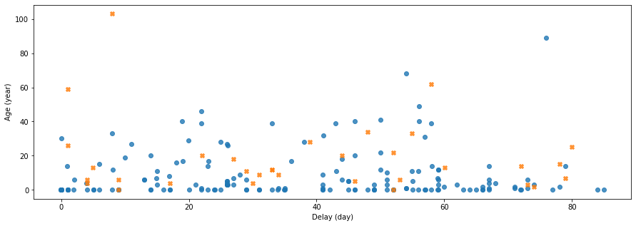

```python
plt.figure(figsize=(15,5))
status_markers = [['Show', 'o'],['No Show', 'X']]

for status, marker in status_markers:
    plot_data = df_clean_subset.loc[df_clean_subset['not_shown'] == status]
    sb.regplot(data = plot_data, x='age', y='appointment_delay', x_jitter=0.04, fit_reg=False , marker = marker)
plt.xlabel('Delay (day)')
plt.ylabel('Age (year)');
```

Regardless of age outliers, patients who are 40 to 60 are more likely to show up to appointment. but it doesn't seem that there is a relationship between age and appointment delay.

> Age correlated to the show-up status could also be different in each gender:

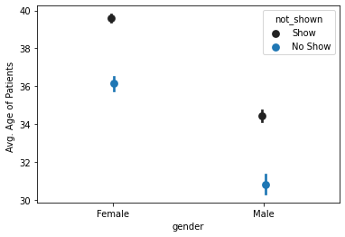

```python
sb.pointplot(data=df_clean, x='gender', y='age', hue='not_shown', color=base_color, linestyles="",dodge = 0.02);
plt.ylabel('Avg. Age of Patients ');
```

In both female and male patients, not showing up to appointments is correlated with the younger patients.

> SMS should be a great tool to remind patients with their appointments, but when the appointment delays its more important to send SMS as a reminder.

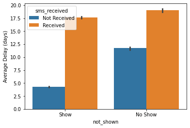

```python
sb.barplot(data=df_clean, x='not_shown', y='appointment_delay', hue = 'sms_received')
plt.ylabel('Average Delay (days)');
```

Although receiving an SMS after a period of time does not seem to be effective but the plot shows that patients who received SMS have higher delay.

> What if merging the three characteristics create different segments in showing up to appointment

```python
hyper_diab_prop = (df_clean.groupby(['not_shown','diabetes','alcoholism']).hypertension.value_counts() /
                          df_clean.groupby(['hypertension','diabetes','alcoholism']).count().not_shown)
hyper_diab_prop = hyper_diab_prop.reset_index(name='proportion')
```

```python
table = pd.pivot_table(hyper_diab_prop, values='proportion', index=['diabetes','hypertension','alcoholism'], columns=['not_shown'], aggfunc=np.sum)
table
```

| diabetes | hypertension | not_shown alcoholism | Show | No Show |
| --- | --- | --- | --- | --- |
| Diabetic | Hypertensive | Alcoholist | 0.820312 | 0.179688 |
|  |  | Not Alcoholist | 0.824238 | 0.175762 |
|  | Not Hypertensive | Alcoholist | 0.828947 | 0.171053 |
|  |  | Not Alcoholist | 0.800145 | 0.199855 |
| Not Diabetic | Hypertensive | Alcoholist | 0.815126 | 0.184874 |
|  |  | Not Alcoholist | 0.829191 | 0.170809 |
|  | Not Hypertensive | Alcoholist | 0.785386 | 0.214614 |
|  |  | Not Alcoholist | 0.790906 | 0.209094 |

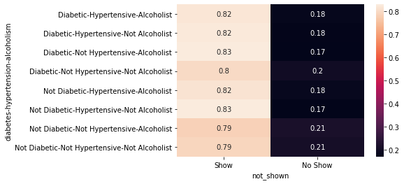

```python
sb.heatmap(table, annot = True);
```

Not showing up highest proportions are shown in three mix-characteristics:

- Not diabetic, not hypertensive and alcoholist patients,
- Not diabetic, not hypertensive and not alcoholist patients,
- Diabetic, Not hypertensive and not alcoholist patients.

### Talk about some of the relationships you observed in this part of the investigation. Were there features that strengthened each other in terms of looking at your feature(s) of interest?

> Patients who are not diabetic, not hypertensive nor alcoholist are having a higher proportion for not showing up to appointments. also we can see that alcoholism become a changing factor for diabetic non-hypertensive patients. If they were non-alcoholists that make the proportion of not showing up higher with observed difference.

### Were there any interesting or surprising interactions between features?

> Age affecting showing up is not totally independent when we also see the gender we can conclude that a different average age is correlated to not showing up to appointment for each gender.

```python
from subprocess import call
call(['python', '-m', 'nbconvert', 'exploration_template.ipynb'])
```